# Module 4 Project Report

Rated-R (Jaan and Jonah)

2023-09-27

## Introduction:

This project explores the allometry and morphology of various ecomorphs within *Anolis*, a genus of reptiles that is remarkably diverse both in species richness and their radiations. An ecomorph is a categorization of multiple species according to their ecological niche, as well as behavior. The anole radiation throughout habitats (including distinct islands and within islands themselves) makes them a useful model organism to study their allometry. In fact, studies performed in Hagey et al. (2017) have generated a sizeable database of anole observations across different species and ecomorphs.  
The central question here is: **How does hind limb length vary with size?** Other related questions delve further into determining potential predictors of this relationship, and correcting for phylogenetic factors. This will be answered by data analysis, both through direct visualization and model design (and model assessment).

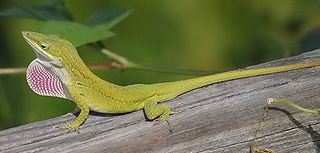

## Methods:

In total, 46 anole species were analyzed morphologically, ecomorphologically, and phylogenetically. Size was approximated as SVL, or snout-vent length, while hind limb length, or HTotal, was measured as the average total hind limb length (from the upper leg to the longest digit). Phylogenetic models were constructed as having traits evolving under either Brownian or Ornstein-Uhlenbeck models, varying independence of co-variables (linear vs. allometric) and analyzed using a phylogenetic generalized least squares (PGLS) procedure.

The phylogenetic tree of *Anolis* species was obtained from Poe et al. (2017) to perform phylogenetic generalized least squares, while the species morphological and ecological data came from Hagey et al. (2017).

Linear models follow the format $HTotal=\alpha*SVL +\beta$. Non-linear allometric models follow the format $HTotal=\alpha*SVL^\beta$.

## Results:

The phylogenetic models were constructed and identified with the following code. Note the inclusion or absence of ecomorph as a covariate.

```r
### phylogenetic GLS models
#PGLS under BM, no ecomorph:
pgls.BM1 <- gls(HTotal~SVL, correlation = corBrownian(1,phy=anole.tree, form=~Species), data=anole.log, method="ML")
#PGLS under BM, with ecomorph:
pgls.BM2 <- gls(HTotal~SVL*Ecomorph2, correlation=corBrownian(1,phy=anole.tree,form=~Species), data=anole.log, method="ML")
#PGLS under OU, no ecomorph:
pgls.OU1 <- gls(HTotal~SVL, correlation=corMartins(0,phy=anole.tree, form=~Species), data=anole.log, method="ML")
#PGLS under OU, with ecomorph:
pgls.OU2 <- gls(HTotal~SVL*Ecomorph2, correlation=corMartins(0,phy=anole.tree, form=~Species), data=anole.log, method="ML")
```

The models’ fit to the data was then assessed using the AIC (Akaike Information Criterion):

Table 1: AIC results for varying linear or allometric models

| model | fit | delta | w |
| --- | --- | --- | --- |
| pgls.BM1 | -63.66118 | 29.319176 | 0.0000004 |
| pgls.BM2 | -92.98036 | 0.000000 | 0.9827289 |
| pgls.OU1 | -57.31864 | 35.661714 | 0.0000000 |
| pgls.OU2 | -84.89770 | 8.082653 | 0.0172706 |

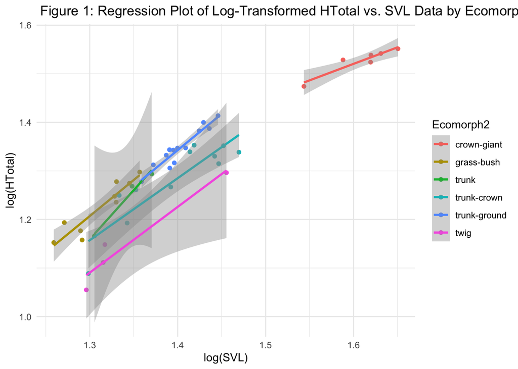

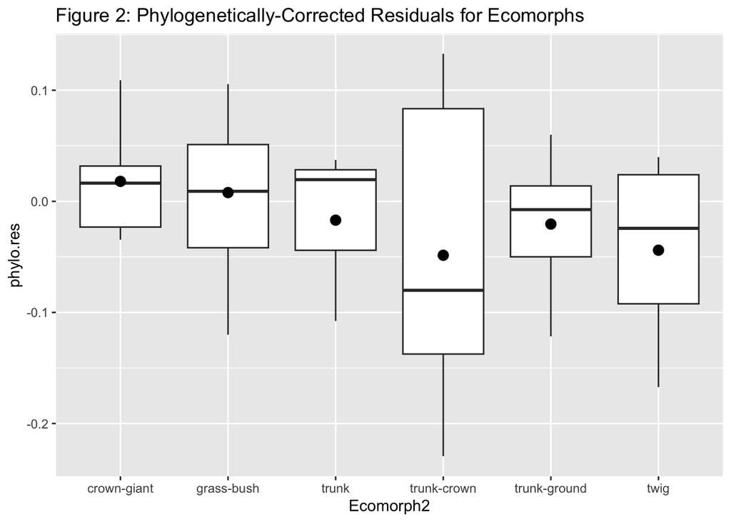